# Real-Time Systems Design – Complete Interview Notes

## Index

1. Introduction: Two Hops
2. Server → Client Communication
   - Polling
   - Long Polling
   - SSE
   - WebSockets
   - WebRTC
3. STUN and TURN
4. Networking Basics
5. Load Balancers
6. Source → Server Communication
   - Pull via Polling
   - Consistent Hashing
   - Pub/Sub
7. Common Interview Deep Dives
8. Real-Time Architecture Examples
9. Interview Decision Tree
10. Final Cheat Sheet

# Introduction: Two Hops

Real-time systems always solve two separate problems:

```
1. Source → Server
2. Server → Client
```

Examples:

- Chat Applications
- Google Docs
- Live Dashboards
- Multiplayer Games
- Video Calls

The biggest interview mistake is focusing only on WebSockets and forgetting how updates reach the server.

⬆ Back to Index

# Server → Client Communication

## 1. Simple Polling

Client repeatedly asks:

```
Anything new?
Anything new?
Anything new?
```

Example:

```
GET /updates every 5 seconds
```

### Advantages

- Very simple
- Stateless
- No special infrastructure

### Disadvantages

- High latency
- Wastes requests
- High DB load

### Use Cases

- Order tracking
- Notifications
- Analytics dashboards

## 2. Long Polling

Client sends request.

Server keeps request open until new data is available.

```
Client ───► Server
      wait...
Server ───► Client
```

Client reconnects immediately.

### Advantages

- Near real-time
- Uses normal HTTP
- Easy implementation

### Disadvantages

- Extra HTTP overhead
- Doesn't scale for high-frequency updates

### Use Cases

- Payment status
- Job completion

## 3. Server-Sent Events (SSE)

Single HTTP connection.

```
Server ─────► Client
```

One-way communication only.

### Advantages

- Lightweight
- Automatic reconnection
- Efficient streaming

### Disadvantages

- No client → server messages
- Some proxies don't support streaming

### Use Cases

- ChatGPT token streaming
- Dashboards
- Stock prices
- Notifications

## 4. WebSockets

Persistent connection.

```
Client ◄────► Server
```

### Advantages

- Very low latency
- Full duplex communication
- Efficient for frequent messages

### Disadvantages

- Stateful
- Harder load balancing
- Need reconnection handling

### Use Cases

- Chat apps
- Multiplayer games
- Collaborative editing
- Live comments

## 5. WebRTC

Peer-to-peer communication.

```
User A ◄────► User B
```

### Advantages

- Lowest latency
- Reduced server costs
- Native video/audio support

### Disadvantages

- Most complex
- NAT/firewall issues

### Use Cases

- Video conferencing
- Voice calls
- Screen sharing
- P2P collaboration

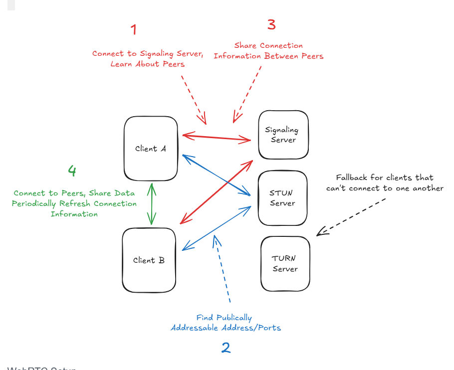

⬆ Back to Index

# STUN and TURN

## Problem

Most devices sit behind NAT and cannot directly communicate.

## STUN (Session Traversal Utilities for NAT)

Helps discover public IP and port.

```
Client → STUN Server
"What is my public IP?"
```

### Pros

- Direct peer-to-peer communication
- Low latency
- Cheap

### Cons

- Doesn't work with every NAT type.

## TURN (Traversal Using Relays around NAT)

Acts as a relay server.

```
Peer A → TURN Server → Peer B
```

### Pros

- Works almost everywhere.

### Cons

- Higher latency
- Expensive
- Consumes server bandwidth

## WebRTC Connection Flow

[output not shown]

⬆ Back to Index

# Networking Basics

## Layer 3 – IP

Responsible for:

- Routing
- Addressing
- Packet delivery

No guarantees:

- Packets may be lost
- Duplicated
- Out of order

## Layer 4 – TCP and UDP

### TCP

- Reliable
- Ordered
- Connection-oriented

Used by:

- HTTP
- SSE
- WebSockets

### UDP

- Fast
- No guarantees
- Connectionless

Used by:

- Gaming
- Streaming
- WebRTC media

## Layer 7 – Application Protocols

Examples:

- HTTP
- DNS
- WebSocket
- WebRTC

⬆ Back to Index

# Load Balancers

## Layer 4 Load Balancer

Works on:

- TCP
- UDP

Routes using:

- IP
- Port

### Advantages

- Fast
- Supports persistent connections

### Best For

- WebSockets

## Layer 7 Load Balancer

Works on:

- HTTP

Can inspect:

- URL
- Headers
- Cookies

### Advantages

- Smart routing
- API routing

### Best For

- HTTP APIs
- SSE

⬆ Back to Index

# Source → Server Communication

## 1. Pull via Polling

```
Client → Server → Database
```

### Advantages

- Simple

### Disadvantages

- High DB load
- High latency

## 2. Consistent Hashing

Assign each user to a single server.

```
User A → Server 1
User B → Server 2
User C → Server 1
```

Need to message User C?

```
hash(User C)
→ Server 1
```

### Why Not Modulo Hashing?

Changing number of servers:

```
userId % N
```

moves almost everyone.

### Consistent Hash Ring

Only small portions move during scaling.

### Advantages

- Minimal disruption
- Great for stateful connections

### Disadvantages

- Complex
- Requires coordination service

### Tools

- ZooKeeper
- etcd

### Use Cases

- Google Docs
- Collaborative editing

## 3. Pub/Sub

```
Producer
    ↓
Kafka / Redis
    ↓
Endpoint Servers
    ↓
Clients
```

### Advantages

- Massive scale
- Efficient broadcasting
- Lightweight endpoint servers

### Disadvantages

- Extra infrastructure
- Pub/Sub bottleneck risk

### Use Cases

- Chat systems
- Notifications
- Social feeds

⬆ Back to Index

# Common Interview Deep Dives

## 1. Reconnection Handling

Problems:

- WiFi drops
- Mobile network changes
- Server restarts

Solutions:

- Heartbeats
- Exponential backoff
- Last message ID

```
Client:
I received until Message #500.
Send everything after #500.
```

## 2. Dead Connection Detection

```
Ping
Pong
Ping
Pong
```

No response:

```
Close connection
Release resources
```

## 3. Celebrity Problem

Celebrity posts to 100M followers.

Bad:

```
Write to 100M users immediately.
```

Good:

```
Cache once
Regional servers
Hierarchical fanout
Pub/Sub
```

## 4. Message Ordering

Problem:

```
Message2 arrives before Message1
```

Solutions:

- Single server
- Single partition
- Sequence numbers
- Logical clocks
- Vector clocks

## 5. Scaling WebSocket Servers

Solutions:

- L4 Load Balancer
- Least-connections strategy
- Dedicated WebSocket service
- Pub/Sub backend

## 6. Deployments

Graceful shutdown:

```
Stop new connections
Drain old connections
Shutdown
```

## 7. Avoid Missing Messages

Use:

- Message IDs
- Sequence numbers
- Replay logs
- Redis Streams
- Kafka offsets

⬆ Back to Index

# Real-Time Architecture Examples

## Chat System

```
Client
   ↓
Load Balancer
   ↓
WebSocket Servers
   ↓
Kafka / Redis
   ↓
Application Services
   ↓
Database
```

## WebRTC System

```
Peer A
   ↓
Signaling Server
   ↓
Peer B

Try STUN
If failed → TURN
```

## Dashboard System

```
Data Producer
      ↓
Kafka
      ↓
SSE Server
      ↓
Browser Dashboard
```

⬆ Back to Index

# Interview Decision Tree

```
Not latency sensitive?
        ↓
     Polling

Need one-way updates?
        ↓
        SSE

Need two-way communication?
        ↓
     WebSocket

Need video/audio?
        ↓
      WebRTC

Need millions of subscribers?
        ↓
      Pub/Sub

Need sticky stateful connections?
        ↓
 Consistent Hashing
```

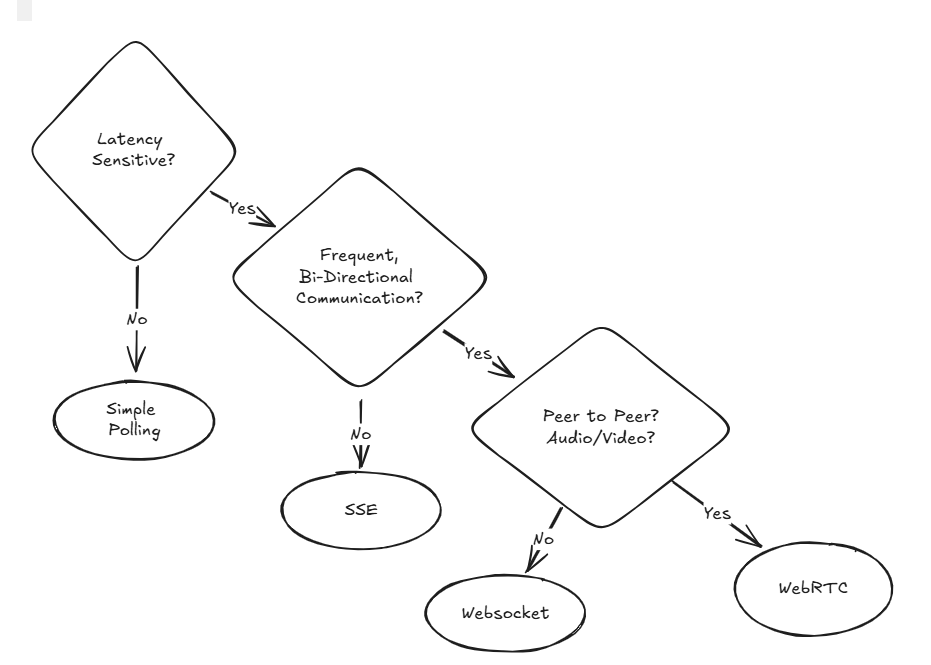

⬆ Back to Index

# Final Interview Cheat Sheet

| Requirement | Solution |
| --- | --- |
| Updates every few seconds | Polling |
| Near real-time | Long Polling |
| Server pushes only | SSE |
| Chat application | WebSocket |
| Video calls | WebRTC |
| Discover public IP | STUN |
| NAT traversal fails | TURN |
| Broadcast to millions | Pub/Sub |
| Stateful connections | Consistent Hashing |
| Dead connections | Heartbeats |
| Ordering guarantee | Single partition |
| Missed messages | Sequence numbers |
| Uneven load | Least-connections load balancer |
| Server restart | Graceful reconnect |

⬆ Back to Index